# In the following, we will explore the relation between melt rates and ocean properties and evaluate different methods to parameterize the observed melt rates as a function of U & T

After reading the data, we start by **fitting the 3-eqn. formulation, searching for an optimal constant $\Gamma_T$-value**. For this, we take Jenkin's drag coefficient and *assume a constant $\Gamma_T$/$\Gamma_S$ ratio of 30*; overall the solutions are rather insensitive of these choices, but it quickly turns out that no satisfying fit can be found, UNLESS:

- assuming a large offset in the observed melt rates (observations ~ 0.4m/yr too high), or,
- assuming a large offset in the observed temperatures (observations ~ 0.15 degC too cold)!

Both of these solutions are not really satisfying, because we can have faith in our observations to be more precise than that. Even though individual strain rate estimates may have an error of 0.5 m/yr, the large number of observations should substantially reduce the error of the mean unless there are any systematic errors that make the uncertainty of the measurement one-sided (which we have discussed and could not see any evidence for). Likewise, for the ocean observations, we know that the observations taken 30 m below the ice base only roughly represent the properties at the outer part of the ice shelf ocean boundary layer (ISOBL), but under the most plausible cases, one would expect temperatures to decrease close to the ice base, rather than to increase (as would be needed to match the parameterization)--and with Stanton numbers (transfer coefficients or friction coefficient), that are about an order of magnitude smaller than what Jenkins et al. 2010 found below FIRS, as will be shown shortly. So, while these optimizations can reproduce the melt rate variability, we do not trust the physics that they would represent. Anyway, this is an important exploration/reference that should be discussed in the paper.

Therefore, we also compare the 3-eqn. formulation to a **purely empirical regression with either linear or non-linear influence of thermal driving and the free flow velocity**, as well as an **piecewise optimized fit of the 3eqn. formulation** with for *varying $\Gamma_T$-values*. The latter method gives as good as a result as any other, with plausible systematic variations as function of the of thermal driving and the free flow velocity (or melt rate), which can easily be understood as a transition between different melting regimes described in this paper: https://journals.ametsoc.org/view/journals/phoc/52/10/JPO-D-21-0317.1.xml (see their Table 4 and Fig. 11 for more details).

A quick word about strain rates :  
In all this analysis, I have used the constant mean strain rate, as it generally provides a better fit with the data than using the linear strain (or even time-varying ones), which reduces both the correlation between the time series (as shown and discussed earlier) and the fit of all of the below methods. Looking closely at the residuals (green curves in the time series below) of the parameterized minus observed melt rates, one can see that they have a slight slope, indicating that there might be a trend in the melt rates that is not captured. In fact, using a constant strain, one gets a slight upward trend in melt rates, while ocean properties woudl suggest a slight downward trend, but this signal is much smaller than what would be obtained if using the linear strain estimate, which is in the order of 50 % of the melting signal. We may discuss this in the margins but at this point, diving further into this seems distractive from the main findings (that the variability in speed and temperature can well explain the observed melt rate variations and that this can be parameterized using the 3eqn formulation when $\Gamma_T$ is adjusted to account for the change between a well mixed and more stratified regime).

I also want to reassess how well the relationship between melt and ocean properties holds at shorter (sub-tidal) time scales. We have measured ~1-2 m tidal elevation amplitudes at M2, but there is no obvious reason, why tides below Fimbulisen should introduce much local bending/ differential stress at this site, which sits in the center of the cavity basin. So, it might be the case that the sub-tidal melt signal can be clearly differentiated, which woudl be exciting. To that end, the data (long time series =: robust statistics) are really great, as I noted even small variations to play out greatly on the fit, e.g. the shape of the distribution changes substantially, if either taking a 36h-low pass filter of the speed (the right way to do it) as opposed to compute the speed of the 36h-low pass filtered the vector components of velocity (which at some point accidentally was done).

But now let's go! First, we need to build some tools for further analysis. Here sits a lot from Elin, who derived the analytical solution of the 3eqn. parameterization with a linearized freezing point, which yields a quadratic equation with many nasty constants. The code has been collapsed in the .html version, so in addition to the figures, you see the printout that is encoded in the script, with some explanatory markdown blocks between.

```
Define constants
FIXME: check ice shelf values...
```

```
Read data...
<KeysViewHDF5 ['dh', 'dh_lin', 'melt_lin', 'num', 'spd2', 'spd_lin', 'spdf2', 'spdr2', 't2', 't_lin', 'tr2', 'vsr', 'vsr_lin']>
langley dh =
-1.74

ApRES dh =
-1.4937287418223097

stake strain =
0.9
ApRES strain =
[-0.44673078]

Plot raw time sereies; FIXME: this plot needs to be mad properly
```

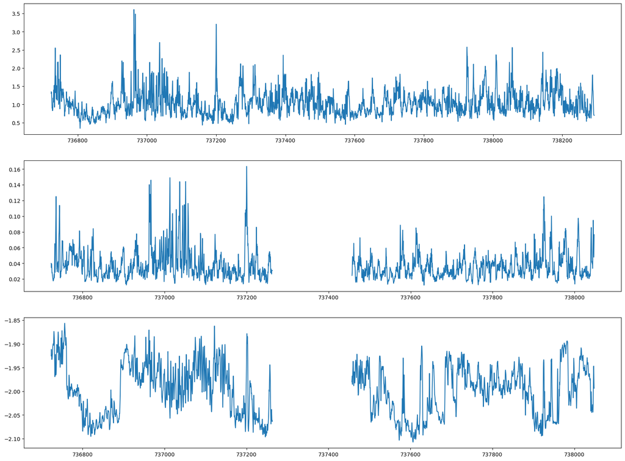

# Suggested input for the paper:

After presenting the raw time series of ApRES (melt, strain) and ocean (T & U) properties, we introduce a section called something like *Functional relationship of melt rates and ocean properties*. Here we present all three methods for parameterizing melting, including the following figures in the following order:

- A time series of parameterized and observed melt + residuals (have 5 panels now, may consider some of them for supplement)
- A histogram showing the distribution of thermal driving/ free flow velocity pairs (and adopting this terminology for observed ocean speed and temperature minus local freezing pointfrom Rosevear 2022). Might consider a second panel that averages melt rates in that space.
- Histograms & quant-quant plots of paraemterized vs observed melt together with fit parameters (suggested 2x2 panel layout bleow)

Then to explore the varying $\Gamma_T$ parameterization, we show:

- a plot of $\Gamma_T$ parameterization in U-Td space. For better comparision with Rosevear et al. 2022, one might add a second x-axis that shows the correspnding friction velocity, using a standard drag coefficient, and ideally with the regime boundary contours from her paper overlaid.
- And a plot that shows the systematic relation between $\Gamma_T$ and the melt rates

All these figures are drafted below, although they show up in different order in the notebook for practical reasons. IMO, this is the most impactful contribution of this dataset, as it relates the observed melting and ocean properties to fundamental relationships, refining our understanding of the applicability of the existing melt rate parameterizations and confirming/ corroberating recent modelling results.

Frome there, we would go on/ branch off and investigate the time variability and procersses that controll chnages of the ocean properties, possibly on sub-tidal time scales, but that is not fully explored yet.

```
Define melt rate function
FIXME: note change in freezign pint defintion on convectve part

In the following, ignore comments about the convective melting from Mandiak et al, this part is currently not in use...

Define r2 score function, used for many purposes below
```

This is the part where we fit the 3eqn. formulation to the data. Instead of looking at the mismatch with the the data itself (r2-metric), we minimizing the mismatch of the quantiles, to get a similar data distribution. The results are not very different, but minimizing the data mismatch tends to produce larger deviations in the distributions (towards a more compressed result of the parameterized melt rates), which are highly skewed with long tails of large values which gives an asymmetric weighting of offsets at smaller values.

Below are some outputs from the process, showing the optimal fit when allowing eitehr

- for an offset in the observed melt rates (pushing all uncertainty/ error into the strain estimate), or,
- for an offset in the observed tehrmal driving (pushing all uncertainties/ error into the representataivness of the obsevred ocean properties 30 m below th ice)

Both attemtps produce a good fit, but with about an order of magnitude smaller $\Gamma_T$ than what Jenkins et al. found and with no plausible explanations for the large offstes in eitehr T or strain that we are getting. One may argue that the truth may liese somewhere in the middle, with smaller offsets in both T and melt, but still the $\Gamma_T$-vaules are a bit odd, and the below fit with variable $\Gamma_T$-vaules shows that we are probably getting the right result for the wrong reason (overfitting).

```
Find optimal fit of melt rate paremeterization
DEFINE f1: variable GammaT, offset in T and U, no melt offset, no convective melt
DEFINE f1: variable GammaT, melt offset, include convective melt, offset in T and U

best initial guess:
[0.1, 2, 0.05, 0.05, 0.2]

1-r2 f(initial_guess)
0.6118665504207741

1-r2 f2(initial_guess)
0.6118665504207741

########## MINIMIZE f1:
  message: Desired error not necessarily achieved due to precision loss.
  success: False
   status: 2
      fun: 0.002350966014619593
        x: [ 1.191e-01  2.000e+00  1.617e-01  2.371e-02  2.000e-01]
      nit: 24
      jac: [ 1.120e-04  0.000e+00  2.051e-04 -5.141e-04  0.000e+00]
 hess_inv: [[ 5.005e-02  0.000e+00 ... -1.328e-02  0.000e+00]
            [ 0.000e+00  1.000e+00 ...  0.000e+00  0.000e+00]
            ...
            [-1.328e-02  0.000e+00 ...  3.570e-03  0.000e+00]
            [ 0.000e+00  0.000e+00 ...  0.000e+00  1.000e+00]]
     nfev: 432
     njev: 70

########## MINIMIZE f2:
 message: Desired error not necessarily achieved due to precision loss.
 success: False
  status: 2
     fun: 0.004243868901323888
       x: [ 2.058e-01  2.000e+00  5.000e-02  6.524e-03 -4.058e-01]
     nit: 56
     jac: [-1.904e-03  0.000e+00  0.000e+00 -6.766e-03 -2.795e-03]
    nfev: 1160
    njev: 192

r2 f(optimized)
0.7543680261280651
r2 f2(optimized)
0.7526145554525759
```

Another way of looking at this is to search for a purely empirical fit of the data, where melting is a function of U & T, or better free flow velocity $U$ and Thermal driving $\Delta_T$, which is defined as the temperature minus the local melting point at the ice-ocean interface (for consistency using the same linearization as in the 3eqn formulation). The simplest form of this is to fit a linear regression to the product of the two:

melting = a ($U$ * $\Delta_T$) + b

A physical interpretation of this would resemble the 2eqn. formulation from Jenkins et al., which assumes that variations of the interface salinity are small, and with the slope a being useful to diagnose the generalized Stanton number $\Gamma_{TS}$ from Jenkins 2012. However, in this case, b should be zero, which does not give a reasonable fit in our case. Instead, we find a comparable offset of 0.55 m/yr (to high in the observations), like for the 3 eqn. formulation. In addition, the distribution of the reatined melt rates is somewaht compressed (not capturing the highest and lowest melt rates), as can be seen in the time sereis and from the quant-quant diagramand (but higher absolute r2) than the 3 eqn. fit with constant $Gamma_T$. An imporvement can be found, when allowing for a non-linear dependency in $U$ and $\Delta_T$, optimizing for the exponents:

melting = a ($U$^0.779 * $\Delta_T$^0.649) + b

```
Optimize linear regression: melt = (T**a * u**b * slope + intercept ) for a and b
best initial guess:
[1, 1]

########## MINIMIZE regression:
 message: Optimization terminated successfully.
 success: True
  status: 0
     fun: 0.015383263481805853
       x: [ 6.488e-01  7.786e-01]
     nit: 4
   direc: [[ 1.000e+00  0.000e+00]
           [-2.250e-02 -2.415e-02]]
    nfev: 143

optimized regression, non-linear
LinregressResult(slope=30.682887837757068, intercept=0.34756404393880325, rvalue=0.8781281364244078, pvalue=0.0, stderr=0.14355648977670665, intercept_stderr=0.0034629521438247672)

regression, linear
LinregressResult(slope=84.10578522045053, intercept=0.5464322324346802, rvalue=0.8795594590790947, pvalue=0.0, stderr=0.39070161342824655, intercept_stderr=0.002631540419820938)

Compute time series and max and min versions based on regression error
r2 regression(optimized)
0.7711090239802032
r2 regression(linear)
0.7736248420555096
```

```
Take a look at the distribution of velocities and temperatures:
```

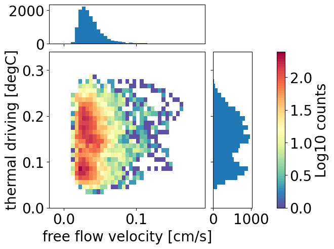

The above scatterplot motivates the approach to vary $\Gamma_T$ as a function of the u & T parameter space. This quickly proved to improve the fit of the 3eqn. parameterization a lot. And it makes sense in terms of the different melting regimes that are described here: https://journals.ametsoc.org/view/journals/phoc/52/10/JPO-D-21-0317.1.xml

The systematic that we find is that $\Gamma_T$ decreases as U & T (the melting) increases, whereas for cold and quiet conditions, the parameters match up well with the Jenkins et al. 2010 values. This is consistent with a transition between a fully mixed (maximum $\Gamma_T$) and the stratified (suppressed mixing) regime. We find a systematic $\Gamma_T$ distribution in T & U space, but also as a function of melt rate, suggesting that there might be a general adjustment that could be made to parameterize melting with melt-rate dependent a suppression factor.

```
try fit minimize melt rate parameterization as fucntion of td

FIXME use log tbins and ubins

best initial guess:
[1, 0, 0, 0, 0]

...will redefine ii now for subsetting the data; restored at the end

Plot scatter melt for all subsets next to T-offset fit for sainity check:
```

```
0.700694909042239
0.7177671320995025
Ok, now restore index ii for full time series
```

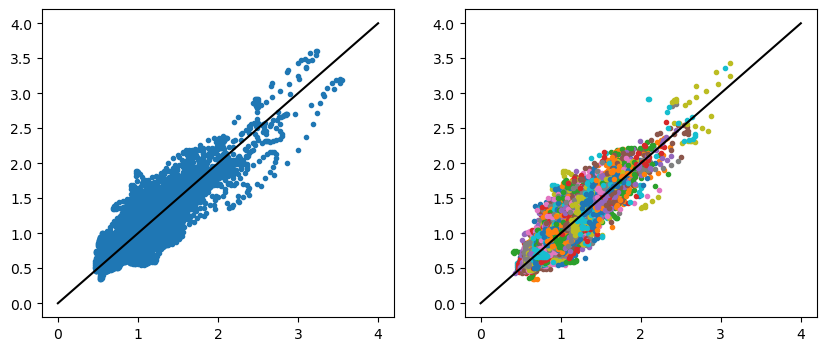

```
Plot and save GammaT as fucntion of free flow velocity and thermal driving:
FIXME: logarithmic axes
```

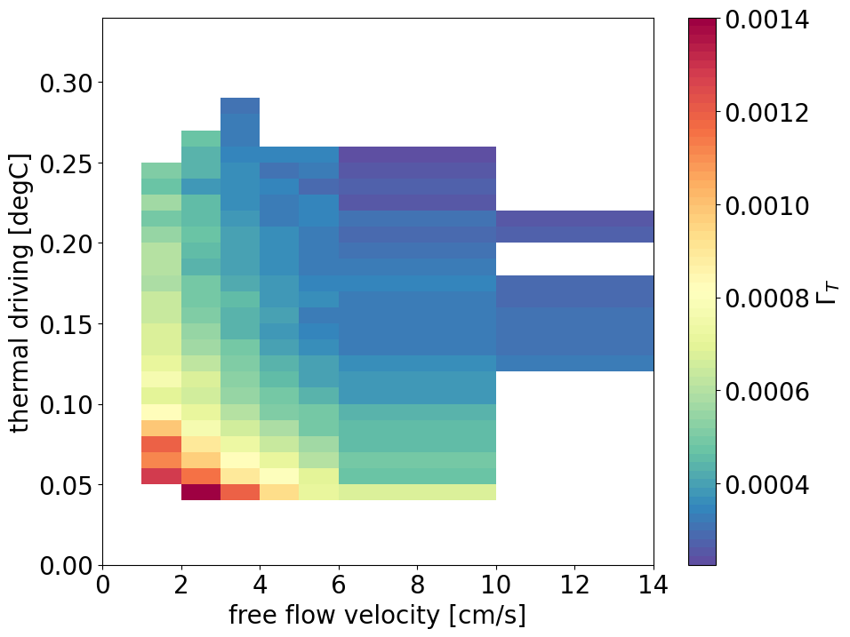

I am really excited about the above plot, and I think this is a really important contribution to this dataset. The red values for cold and quiescent conditions are in close agreement with the Jenkins et al. 2010 values, confirming the empirical values for a well mixed regime. In contrast, for greater velocities, and in particular for higher thermal driving, the transfer coefficient drops (assuming that the drag coefficient stays unchanged) by about an order of magnitude. This is consistent with the transition into a more stratified regime, where heat fluxes are suppressed by vertical density gradients in the ISOBL (and consistent with Rosevear et al. 2022, e.g. Fig 9).

On the one hand, this shows that melting at Fimbulisen (M2) is not happening in a single regime, but that it varies. Here one could easily branch off to investigate if there is a systematic change to it, and I assume that we woudl quickly see a seasonal cycle, where during the arrival of ASW with warmer temperatures in July (Lauber et al. 2024, TC), the stratified regime dominates, while during times when ISW and colder temperatures are observed in Aril to June at the mooring, the well-mixed regime dominates.

Another important an more general implication of these results is that (a) the 3eqn. formulation seems to work really well in the quiescent and cold mixed regime (as others have pointed out), while (at least for Fimbulisen/ M2) an empirical relationship may be found (as illustrated in the above figure), on how the transition into a faster-flowing and warmer regime will suppress the transfer coefficient. Who knows, maybe the relationship for $\gamma_T$ (now talking about the transfer coefficient itself, not the Stanton number) as a function of thermal driving and free flow velocity that we see here, is a general one. In that case, these observations could immediately hep to improve formulations of basal melting in ocean models (which now use a constant gamma to tune for whatever case). I think this is really really exciting, and I suggest that we prioritize getting this point across in the paper.

In fact, with some more work, one could try to scrutinize existing parameterizations that account for the suppression of the transfer coefficient in the presence of stratification (mainly applied in sea ice) by estimating the stratification from the interface salinity, which can be diagnosed from the 3eqn. formulation. In this way, the ISOBL is simpler than the sea ice case, because freshwater fluxes are more constrained (along the Gade lines). Still, there will be slope, roughness, and pressure, which, together with an unknown vertical profile, leaves enough ambiguity, but at least we see some consistent, systematic change here.

Another way of looking at it is that--if all stratification is caused by interface fluxes, i.e. meltwater input--the transfer coefficient may be a function of the melt rate itself. A quick-an-dirty plot-and-see exercise indicates that this might indeed be the case here, where the square root of $\Gamma_T$ increases (roughly linear) with the inverse of the melt rates. Again, via the 3eqn. formulation and an expression for the BL-stratification, this relationship may possibly be linked/ derived, and again with the caveats of other environmental properties making things more complicated for a general approach.

Regardless fo how far we push this, I think the above and below figures should be presented and discussed in the paper, as the most general result of this study.

```
Plot and save GammaT as fucntion of melt rate:
FIXME: explore further for robust relationship...
```

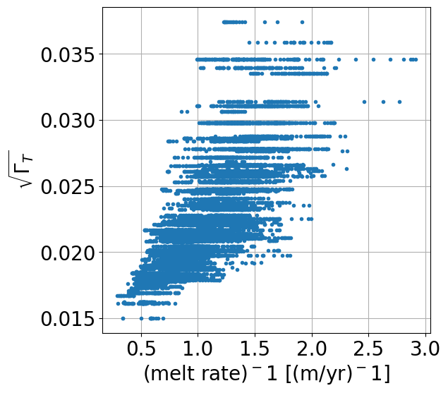

```
Next, to parameterize melt rates,, we need a mapping (2D interpolation) of GammaT as function of free flow velocity and thermal driving
For this, we use the scipy LinearNDInterpolator function...

...interpolating GammaT values for all U & T pairs...
...which we will use in a new melt rates function...
...to copmute the melt rates for all available velocities and tempeartures...
...Done!
```

```
length of overlapping sereies:
13562

crop to gamma-parameterized series
13481

FIXME: add metrics for line reg
```

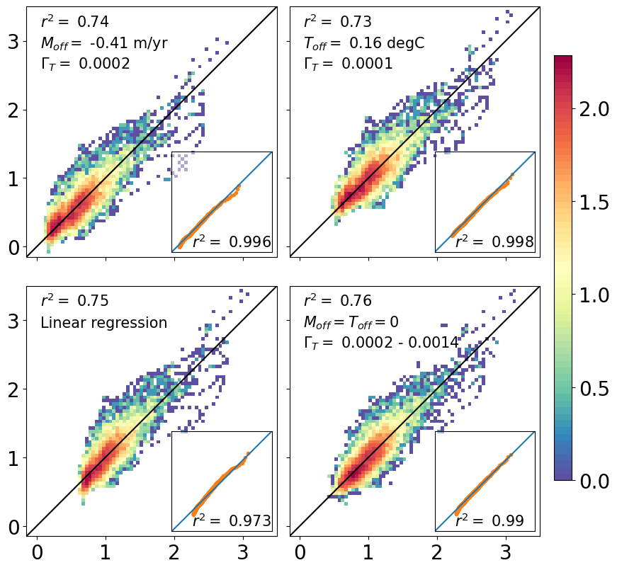

```
restore index into full time sereies
```

Above is the figure that illustrates how the different parameterizations are able to capture the observed melt rate variability. The regression is shown for the linear relationship of U and T, to illustrate the "compression effect" on the data (quantiles bending/ sloping away from 45deg line), whereas the solution with sub-linear response to U and T gives a very similar result as the other non-linear parameterizations.

Below are the time series (not tidy/ beautiful yet) of the observed (blue) and parameterized (orange) melt and their residuals (parameterized minus observed = green). Maybe not all panels need to go into the main part of the paper, but an overview should at least be in the appendix and a selection in the paper. Maybe the ones that we use for the melt rate parameterization, but at least the version with varying $\Gamma_T$, as we perform further analysis on it.

```
and here are some time sereis plots of the parameterized and observed melt rates, together with the residuals:
FIXME: cosmetics on axes, labels etc.
```

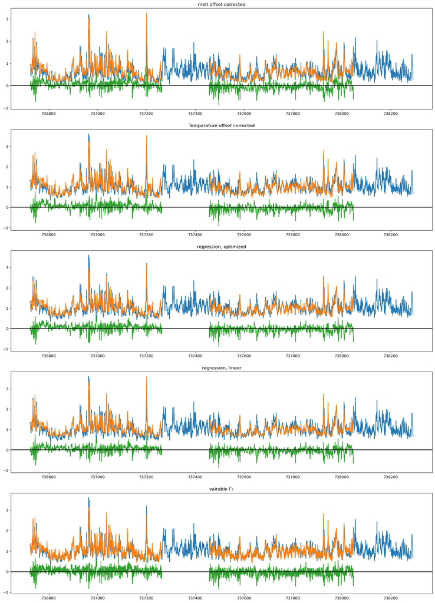

The stuff below here is for processing the full-length ocean time series and parameterizing melt rates "backward" in time. So far, I only saved the data in a format for Elin to work with the time-scale analysis, but we also need to decide how to incorporate/ represent the melt rate errors that come put of this.

```
Load full ocean time series for long-term parameterization
Read full M2 ocean data...
<KeysViewHDF5 ['num', 'spd', 'spdf36', 't', 'tf36']>
```

```
Plot raw time sereies; FIXME: this plot needs to be mad properly
```

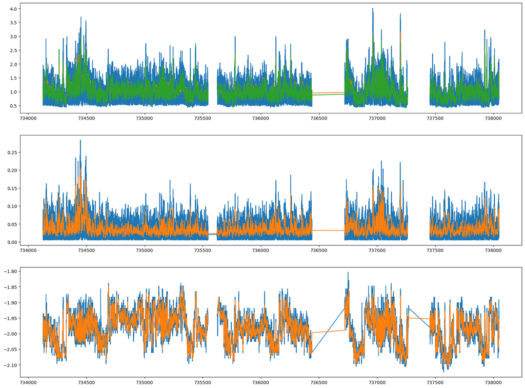

A file with the data, full time sereis, has been saved. Therea are raw hourly series and 36h low-pass filtered series (*f36). melting has been obatined from regression with the optimized non-linear realtionship as described above and with the varying $\Gamma_T$ method. The data uses the native mooring time stamps. Probably the series need checking for gaps and/or large jumps in time which will sho up in the frequency space etc (see straight lines above).

Some loose thoughts on the relation of melt rates to ocean properties.  
At zero order, ice ablation increases with larger ambient ocean temperature and velocity as both factors enhance the fluxes across the ice-ocean boundary layer. From the conservation of heat and salt, a quadratic equation for the ablation rate can be found that generally yields a non-linear response to changes in ambient thermal driving T* and friction velocity u* = C_d^(1/2)*U_0, while a linearized expression is obtained under the assumption of small variations of the salinity in the boundary layer.

THe time-varying strain and its trend would indicate a decreasing trend in melt rate that is not supported by the ocean observations. If the linear trend in the strain is related the ice dynamics of the basal channel, this may also affect the slope and hence the plume velocity, providing an explanation for a trend in melt rates that woudl not be observed as changes in ocean properties 30-40 m below the ice base where our mooring is situated. The discrepancy is, however, large, and the better fit of a constant mean strain with the ocean obs is encouraging. The offset in temperature/ thermal driving is still hard to explain (needing a temperature inversion below the ice base), casting doubt on the absolute magnitude of the observed (parameterized) melting (and strain). But later we found tht this probably connects to varying transfer coefficients